# 로지스틱 회귀모형

- binomial 로지스틱 회귀모형을 하기위해 VMS_keyword 데이터를 범주화(0, 1)하여 Risk 변수 생성 (엑셀로 가변수처리)
- Risk 변수를 반응변수로하여 로지스틱 회귀분석 진행

```r
library(tidyverse)
library(ggplot2)
library(GGally)
library(grid)
library(gridExtra)
library(knitr)
library(kableExtra)
```

```r
setwd("C:/Users/Administrator/Desktop/data")

df <- read_csv("road_2019.csv",locale=locale('ko',encoding='euc-kr'))
```

```r
df$VMS_keyword <- as.factor(df$VMS_keyword)
df$pave <- as.factor(df$pave)
df$surface <- as.factor(df$surface)
df$bridge_surface <- as.factor(df$bridge_surface)
df$classification <- as.factor(df$classification)
df$bridge_lane <- as.factor(df$bridge_lane)
df$bridge_pave <- as.factor(df$bridge_pave)
df$bridge <- as.factor(df$bridge)
df$tunnel <- as.factor(df$tunnel)
df$grooving <- as.factor(df$grooving)
df$ice_leak <- as.factor(df$ice_leak)
df$weather <- as.factor(df$weather)
```

```r
# 기존변수를 이용해서 새 변수 만들기
df <- df %>%
  mutate(cz_length = abs(df$czend - df$czstart)) # 콘존 길이
```

```r
df_numeric <- df[,c(25, 29:43, 45, 46)] # 데이터에서 수치형 변수만 추출
```

| Risk | freq | prop |
| --- | --- | --- |
| Not Risk | 125285 | 0.829702 |
| Risk | 25715 | 0.170298 |

- VMS_keyword 변수에서 해당 지역이 결빙, 노면미끄럼, 노면습기, 눈, 비, 비/눈예보, 비예보, 어는비에 대해서는 범주 1로, 이상없음은 범주를 0으로 가변수 처리하였습니다.

## 가정성

1. Binary or Binomial Response : 반응변수가 이진 또는 이항변수 임을 보이기
2. Independence : 관측치들이 독립이어야한다.
3. Variance Structure: binary response의 경우 p(1− p), p = .5일 때 가장 큼. 즉 분산이 평균 p와 관련이 있다.
4. Linearity : 로그 오즈 (odds ratio) log(p/1−p)가 공변량의 선형함수

### 가정1 : 반응변수의 형태

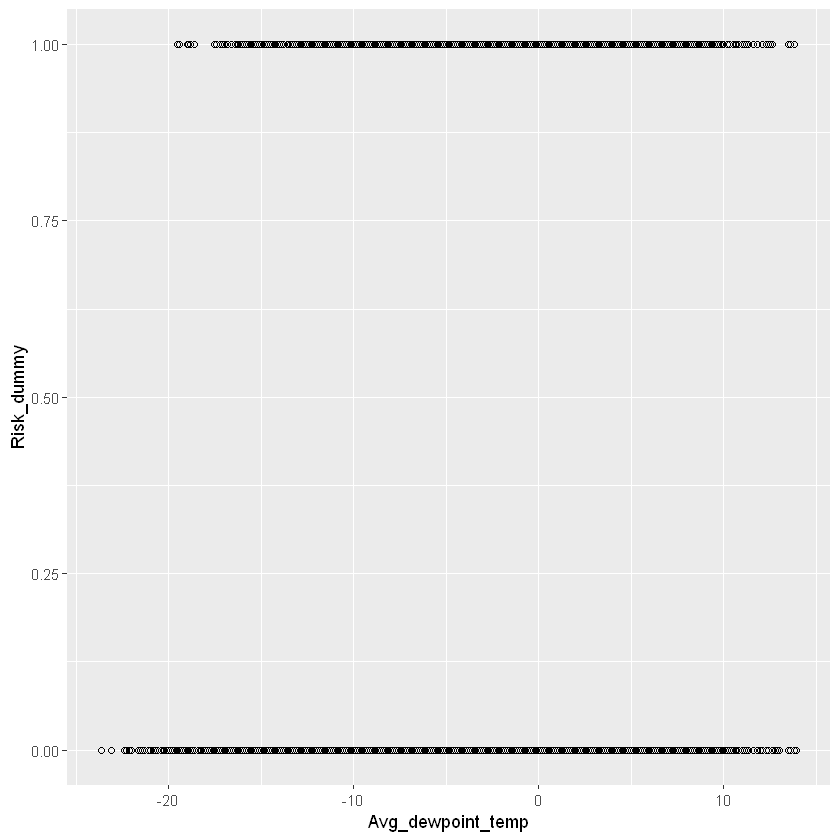

```r
ggplot(df, aes(x = Avg_dewpoint_temp, y = Risk_dummy)) +
  geom_point(shape=1)
```

### 가정 2 : 독립성

- 우리가 찾은 데이터의 관측치는 콘존단위로 구성이 되있다. 따라서 콘존ID 별로 각각 다른 데이터기 때문에 독립성을 만족한다.

### 가정 4 : 선형성

```r
# 수치형 예측변수 선택하기
df1 <- subset(df, df$date==20190101) # 데이터 양이 많아 주피터 노트북 출력에 과부하가 생겨 하루치 데이터로 설정하였습니다.

df1_numeric <- df1[,c(25, 29:43, 45, 46)] # 수치형변수만 불러와서 데이터프레임
colnames(df1_numeric)
df1_numeric <- df1_numeric[,-c(3, 5, 13)] # 다중공선성 영향주는 변수 제거

predictors <- colnames(df1_numeric)
```

1. 'traffic'

2. 'Avg_temp'

3. 'Mini_temp'

4. 'Mini_temp_time'

5. 'Max_temp'

6. 'Max_temp_time'

7. 'precipitation_duration_time'

8. 'day_precipitation'

9. 'Max_windspeed'

10. 'Wind_direction'

11. 'Avg_windspeed'

12. 'Avg_dewpoint_temp'

13. 'Avg_relative_humidity'

14. 'Sunlight_time'

15. 'Deepest_snow'

16. 'Avg_ground_temp'

17. 'Fog_time'

18. 'Risk_dummy'

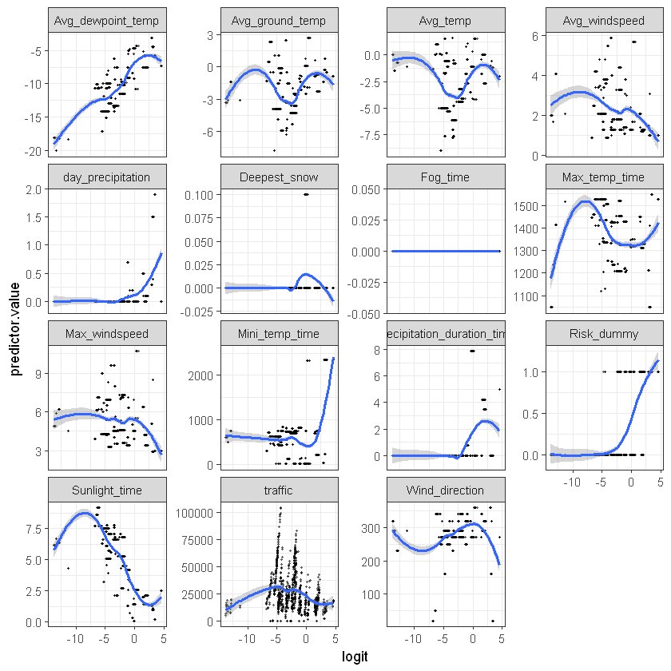

```r
# 로짓 바인딩 및 데이터 정리
model <- glm(Risk_dummy ~., data = df1_numeric, family = binomial)

probabilities <- predict(model, type = "response")


df1_numeric <- df1_numeric %>%
                      mutate(logit = log(probabilities/(1-probabilities))) %>%
                      gather(key = "predictors", value = "predictor.value", -logit)

ggplot(df1_numeric, aes(logit, predictor.value))+
  geom_point(size = 0.5, alpha = 0.5) +
  geom_smooth(method = "loess") +
  theme_bw() +
  facet_wrap(~predictors, scales = "free_y")
```

## 모형화

### Model 0

```r
model0 = glm(Risk_dummy ~ Avg_dewpoint_temp, family=binomial, data=df)
summary(model0)
exp(0.062068)
```

```
Call:
glm(formula = Risk_dummy ~ Avg_dewpoint_temp, family = binomial,
    data = df)

Deviance Residuals:
    Min       1Q   Median       3Q      Max
-0.9629  -0.6465  -0.5642  -0.4509   2.3120

Coefficients:
                   Estimate Std. Error z value Pr(>|z|)
(Intercept)       -1.390834   0.007362 -188.92   <2e-16 ***
Avg_dewpoint_temp  0.062068   0.001097   56.56   <2e-16 ***
---
Signif. codes:  0 '***' 0.001 '**' 0.01 '*' 0.05 '.' 0.1 ' ' 1

(Dispersion parameter for binomial family taken to be 1)

    Null deviance: 137820  on 150999  degrees of freedom
Residual deviance: 134479  on 150998  degrees of freedom
AIC: 134483

Number of Fisher Scoring iterations: 4
```

1.06403469662741

- 유의확률이 2e-16 이므로 0 에 매우 가깝기 때문에 이슬점 변수가 위험변수(결빙위험)에 영향을 준다고 판단할 수 있다.
- 회귀계수 0.062068을 해석하면, 우선 반응변수가 로짓이기 때문에 역함수를 취해 exponential 을 붙여줘야한다.
- exp(0.062068) = 약 1.06 (이 값을 이슬점에 대한 오즈비(odds ratio) 라고 한다.)  
  이슬점이 한 단위 증가하면 해당 노면에 대한 위험률이 1.06배 증가함.
- AIC 값은 134483 (최종 모델 평가에 기여)

### Model 1

```r
model1 = glm(Risk_dummy ~ Avg_dewpoint_temp+pave, family=binomial, data=df)
summary(model1)
```

```
Call:
glm(formula = Risk_dummy ~ Avg_dewpoint_temp + pave, family = binomial,
    data = df)

Deviance Residuals:
    Min       1Q   Median       3Q      Max
-0.9781  -0.6484  -0.5631  -0.4523   2.3335

Coefficients:
                   Estimate Std. Error  z value Pr(>|z|)
(Intercept)       -1.449659   0.011008 -131.688  < 2e-16 ***
Avg_dewpoint_temp  0.061788   0.001099   56.239  < 2e-16 ***
pave콘크리트       0.102136   0.014027    7.281  3.3e-13 ***
---
Signif. codes:  0 '***' 0.001 '**' 0.01 '*' 0.05 '.' 0.1 ' ' 1

(Dispersion parameter for binomial family taken to be 1)

    Null deviance: 137820  on 150999  degrees of freedom
Residual deviance: 134426  on 150997  degrees of freedom
AIC: 134432

Number of Fisher Scoring iterations: 4
```

```r
exp(0.102136)
```

1.10753408612163

- 범주형 예측변수인 pave 항을 추가하였다.
- 도로포장이 아스팔트보다 콘크리트일때의 위험률이 exp(0.1023136) = 약 1.1 배 (콘크리트때 조금 더 위험하다.)
- AIC 134432 (AIC 값이 줄어들어 더 나은 모형)

### Model 2

```r
model2 = glm(Risk_dummy ~ Avg_dewpoint_temp+pave+classification, family=binomial, data=df)
summary(model2)
```

```
Call:
glm(formula = Risk_dummy ~ Avg_dewpoint_temp + pave + classification,
    family = binomial, data = df)

Deviance Residuals:
    Min       1Q   Median       3Q      Max
-1.0889  -0.6486  -0.5615  -0.4474   2.5284

Coefficients:
                     Estimate Std. Error z value Pr(>|z|)
(Intercept)          -0.99240    0.05199 -19.088   <2e-16 ***
Avg_dewpoint_temp     0.06195    0.00110  56.335   <2e-16 ***
pave콘크리트          0.12971    0.01416   9.160   <2e-16 ***
classification터널부 -1.37497    0.09942 -13.830   <2e-16 ***
classification토공부 -0.47153    0.05267  -8.952   <2e-16 ***
---
Signif. codes:  0 '***' 0.001 '**' 0.01 '*' 0.05 '.' 0.1 ' ' 1

(Dispersion parameter for binomial family taken to be 1)

    Null deviance: 137820  on 150999  degrees of freedom
Residual deviance: 134206  on 150995  degrees of freedom
AIC: 134216

Number of Fisher Scoring iterations: 4
```

### Model 3

```r
model3 = glm(Risk_dummy ~ Avg_dewpoint_temp+pave+classification+surface, family=binomial, data=df)
summary(model3)
```

```
Call:
glm(formula = Risk_dummy ~ Avg_dewpoint_temp + pave + classification +
    surface, family = binomial, data = df)

Deviance Residuals:
    Min       1Q   Median       3Q      Max
-1.1149  -0.6513  -0.5579  -0.4333   2.5236

Coefficients:
                       Estimate Std. Error z value Pr(>|z|)
(Intercept)           -0.101150   0.129852  -0.779  0.43600
Avg_dewpoint_temp      0.061048   0.001105  55.250  < 2e-16 ***
pave콘크리트          -0.632895   0.105201  -6.016 1.79e-09 ***
classification터널부  -1.345962   0.102563 -13.123  < 2e-16 ***
classification토공부  -0.455291   0.058119  -7.834 4.73e-15 ***
surfaceJCP            -0.158497   0.049903  -3.176  0.00149 **
surfaceJRCP            0.540567   0.104467   5.175 2.28e-07 ***
surfaceLMC            -0.278072   0.152562  -1.823  0.06835 .
surfacePBSC           -0.519150   0.117624  -4.414 1.02e-05 ***
surfacePSMA           -0.717113   0.126054  -5.689 1.28e-08 ***
surfaceSBS            -0.341482   0.173689  -1.966  0.04929 *
surfaceSMA            -1.299838   0.118214 -10.996  < 2e-16 ***
surface일반아스팔트   -0.816956   0.116863  -6.991 2.73e-12 ***
surface콘크리트마모층  0.077805   0.102164   0.762  0.44631
---
Signif. codes:  0 '***' 0.001 '**' 0.01 '*' 0.05 '.' 0.1 ' ' 1

(Dispersion parameter for binomial family taken to be 1)

    Null deviance: 137820  on 150999  degrees of freedom
Residual deviance: 133590  on 150986  degrees of freedom
AIC: 133618

Number of Fisher Scoring iterations: 4
```

### Model 4

```r
model4 = glm(Risk_dummy ~ Avg_dewpoint_temp+pave+classification+surface+traffic, family=binomial, data=df)
summary(model4)
```

```
Call:
glm(formula = Risk_dummy ~ Avg_dewpoint_temp + pave + classification +
    surface + traffic, family = binomial, data = df)

Deviance Residuals:
    Min       1Q   Median       3Q      Max
-1.1152  -0.6512  -0.5582  -0.4336   2.5238

Coefficients:
                        Estimate Std. Error z value Pr(>|z|)
(Intercept)           -9.193e-02  1.313e-01  -0.700  0.48371
Avg_dewpoint_temp      6.103e-02  1.106e-03  55.180  < 2e-16 ***
pave콘크리트          -6.356e-01  1.054e-01  -6.029 1.65e-09 ***
classification터널부  -1.347e+00  1.026e-01 -13.131  < 2e-16 ***
classification토공부  -4.563e-01  5.816e-02  -7.846 4.29e-15 ***
surfaceJCP            -1.608e-01  5.012e-02  -3.208  0.00133 **
surfaceJRCP            5.419e-01  1.045e-01   5.186 2.15e-07 ***
surfaceLMC            -2.843e-01  1.531e-01  -1.857  0.06327 .
surfacePBSC           -5.232e-01  1.180e-01  -4.434 9.24e-06 ***
surfacePSMA           -7.204e-01  1.263e-01  -5.704 1.17e-08 ***
surfaceSBS            -3.468e-01  1.741e-01  -1.992  0.04633 *
surfaceSMA            -1.302e+00  1.184e-01 -11.000  < 2e-16 ***
surface일반아스팔트   -8.197e-01  1.171e-01  -7.002 2.53e-12 ***
surface콘크리트마모층  7.618e-02  1.022e-01   0.745  0.45609
traffic               -1.585e-07  3.221e-07  -0.492  0.62275
---
Signif. codes:  0 '***' 0.001 '**' 0.01 '*' 0.05 '.' 0.1 ' ' 1

(Dispersion parameter for binomial family taken to be 1)

    Null deviance: 137820  on 150999  degrees of freedom
Residual deviance: 133590  on 150985  degrees of freedom
AIC: 133620

Number of Fisher Scoring iterations: 4
```

- 교통량 변수(traffic) 을 넣었더니 오히려 모형 적합도가 떨어짐 원인은? (회귀분석에서는 교통량 변수 제거)
- 예상원인 : 점검 중일 때 교통량이 -1인 여부, 데이터 분산이 크기 때문에 정규화 또는 표준화 필요성 요구

### Model 5

```r
model5 = glm(Risk_dummy ~ Avg_dewpoint_temp+pave+classification+surface+ice_leak, family=binomial, data=df)
summary(model5)
```

```
Call:
glm(formula = Risk_dummy ~ Avg_dewpoint_temp + pave + classification +
    surface + ice_leak, family = binomial, data = df)

Deviance Residuals:
    Min       1Q   Median       3Q      Max
-1.1103  -0.6516  -0.5570  -0.4318   2.5246

Coefficients:
                       Estimate Std. Error z value Pr(>|z|)
(Intercept)           -0.110389   0.130490  -0.846  0.39757
Avg_dewpoint_temp      0.061239   0.001106  55.393  < 2e-16 ***
pave콘크리트          -0.635856   0.105965  -6.001 1.97e-09 ***
classification터널부  -1.329289   0.102598 -12.956  < 2e-16 ***
classification토공부  -0.461447   0.058143  -7.936 2.08e-15 ***
surfaceJCP            -0.162790   0.049921  -3.261  0.00111 **
surfaceJRCP            0.559767   0.104510   5.356 8.50e-08 ***
surfaceLMC            -0.265864   0.152588  -1.742  0.08144 .
surfacePBSC           -0.536704   0.118380  -4.534 5.79e-06 ***
surfacePSMA           -0.719566   0.126699  -5.679 1.35e-08 ***
surfaceSBS            -0.408699   0.174424  -2.343  0.01912 *
surfaceSMA            -1.311366   0.118910 -11.028  < 2e-16 ***
surface일반아스팔트   -0.821021   0.117558  -6.984 2.87e-12 ***
surface콘크리트마모층  0.096631   0.102204   0.945  0.34442
ice_leak1              0.162563   0.019897   8.170 3.08e-16 ***
---
Signif. codes:  0 '***' 0.001 '**' 0.01 '*' 0.05 '.' 0.1 ' ' 1

(Dispersion parameter for binomial family taken to be 1)

    Null deviance: 137820  on 150999  degrees of freedom
Residual deviance: 133525  on 150985  degrees of freedom
AIC: 133555

Number of Fisher Scoring iterations: 4
```

- 기존에 공공기관에서 발표한 결빙취약지역(ice_leak) 일수록 1.2배 더 위험하다.
- 당연한 변수여서 모형에서 제외

### Model 6

```r
model6 = glm(Risk_dummy ~ Avg_dewpoint_temp+pave+classification+surface+e_elevation, family=binomial, data=df)
summary(model6)
```

```
Call:
glm(formula = Risk_dummy ~ Avg_dewpoint_temp + pave + classification +
    surface + e_elevation, family = binomial, data = df)

Deviance Residuals:
    Min       1Q   Median       3Q      Max
-1.1448  -0.6521  -0.5542  -0.4274   2.5386

Coefficients:
                        Estimate Std. Error z value Pr(>|z|)
(Intercept)           -7.965e-02  1.310e-01  -0.608 0.543159
Avg_dewpoint_temp      6.284e-02  1.112e-03  56.513  < 2e-16 ***
pave콘크리트          -6.776e-01  1.066e-01  -6.357 2.06e-10 ***
classification터널부  -1.448e+00  1.028e-01 -14.083  < 2e-16 ***
classification토공부  -5.268e-01  5.830e-02  -9.036  < 2e-16 ***
surfaceJCP            -1.803e-01  4.995e-02  -3.609 0.000307 ***
surfaceJRCP            6.283e-01  1.047e-01   6.004 1.93e-09 ***
surfaceLMC            -2.980e-01  1.527e-01  -1.952 0.050920 .
surfacePBSC           -5.161e-01  1.189e-01  -4.339 1.43e-05 ***
surfacePSMA           -7.933e-01  1.273e-01  -6.232 4.60e-10 ***
surfaceSBS            -3.834e-01  1.746e-01  -2.196 0.028113 *
surfaceSMA            -1.341e+00  1.195e-01 -11.221  < 2e-16 ***
surface일반아스팔트   -8.708e-01  1.182e-01  -7.369 1.72e-13 ***
surface콘크리트마모층  7.457e-02  1.022e-01   0.730 0.465695
e_elevation            1.244e-03  6.503e-05  19.133  < 2e-16 ***
---
Signif. codes:  0 '***' 0.001 '**' 0.01 '*' 0.05 '.' 0.1 ' ' 1

(Dispersion parameter for binomial family taken to be 1)

    Null deviance: 137820  on 150999  degrees of freedom
Residual deviance: 133249  on 150985  degrees of freedom
AIC: 133279

Number of Fisher Scoring iterations: 4
```

### Model 7

```r
model7 = glm(Risk_dummy ~ Avg_dewpoint_temp+pave+classification+surface+e_elevation+Avg_windspeed, family=binomial, data=df)
summary(model7)
```

```
Call:
glm(formula = Risk_dummy ~ Avg_dewpoint_temp + pave + classification +
    surface + e_elevation + Avg_windspeed, family = binomial,
    data = df)

Deviance Residuals:
    Min       1Q   Median       3Q      Max
-1.7836  -0.6447  -0.5282  -0.4041   2.5415

Coefficients:
                        Estimate Std. Error z value Pr(>|z|)
(Intercept)           -7.471e-01  1.283e-01  -5.825 5.71e-09 ***
Avg_dewpoint_temp      6.957e-02  1.126e-03  61.782  < 2e-16 ***
pave콘크리트          -5.034e-01  1.020e-01  -4.935 8.02e-07 ***
classification터널부  -1.350e+00  1.038e-01 -13.000  < 2e-16 ***
classification토공부  -3.820e-01  5.894e-02  -6.481 9.11e-11 ***
surfaceJCP            -3.641e-01  5.027e-02  -7.243 4.38e-13 ***
surfaceJRCP            2.762e-01  1.059e-01   2.608   0.0091 **
surfaceLMC            -3.670e-01  1.548e-01  -2.371   0.0177 *
surfacePBSC           -4.805e-01  1.145e-01  -4.196 2.72e-05 ***
surfacePSMA           -1.024e+00  1.237e-01  -8.277  < 2e-16 ***
surfaceSBS            -3.400e-01  1.728e-01  -1.968   0.0491 *
surfaceSMA            -1.329e+00  1.154e-01 -11.518  < 2e-16 ***
surface일반아스팔트   -9.377e-01  1.141e-01  -8.218  < 2e-16 ***
surface콘크리트마모층  4.101e-02  1.026e-01   0.400   0.6894
e_elevation            1.488e-03  6.438e-05  23.108  < 2e-16 ***
Avg_windspeed          2.775e-01  5.754e-03  48.230  < 2e-16 ***
---
Signif. codes:  0 '***' 0.001 '**' 0.01 '*' 0.05 '.' 0.1 ' ' 1

(Dispersion parameter for binomial family taken to be 1)

    Null deviance: 137820  on 150999  degrees of freedom
Residual deviance: 131010  on 150984  degrees of freedom
AIC: 131042

Number of Fisher Scoring iterations: 4
```

### Model 8

```r
model8 = glm(Risk_dummy ~ Avg_dewpoint_temp+pave+classification+surface+e_elevation+Avg_windspeed+Sunlight_time, family=binomial, data=df)
summary(model8)
```

```
Call:
glm(formula = Risk_dummy ~ Avg_dewpoint_temp + pave + classification +
    surface + e_elevation + Avg_windspeed + Sunlight_time, family = binomial,
    data = df)

Deviance Residuals:
    Min       1Q   Median       3Q      Max
-2.0288  -0.5792  -0.4135  -0.3173   2.7427

Coefficients:
                        Estimate Std. Error  z value Pr(>|z|)
(Intercept)            5.857e-01  1.373e-01    4.267 1.98e-05 ***
Avg_dewpoint_temp      2.011e-02  1.276e-03   15.758  < 2e-16 ***
pave콘크리트          -5.505e-01  1.091e-01   -5.045 4.53e-07 ***
classification터널부  -1.466e+00  1.086e-01  -13.500  < 2e-16 ***
classification토공부  -4.778e-01  6.262e-02   -7.630 2.34e-14 ***
surfaceJCP            -3.536e-01  5.319e-02   -6.648 2.98e-11 ***
surfaceJRCP            2.836e-01  1.127e-01    2.517 0.011844 *
surfaceLMC            -2.749e-01  1.649e-01   -1.667 0.095448 .
surfacePBSC           -4.647e-01  1.222e-01   -3.803 0.000143 ***
surfacePSMA           -1.128e+00  1.319e-01   -8.556  < 2e-16 ***
surfaceSBS            -3.007e-01  1.849e-01   -1.626 0.103975
surfaceSMA            -1.484e+00  1.231e-01  -12.048  < 2e-16 ***
surface일반아스팔트   -9.619e-01  1.218e-01   -7.899 2.82e-15 ***
surface콘크리트마모층  1.076e-01  1.089e-01    0.988 0.323236
e_elevation            1.322e-03  6.849e-05   19.302  < 2e-16 ***
Avg_windspeed          3.266e-01  6.140e-03   53.196  < 2e-16 ***
Sunlight_time         -2.562e-01  2.391e-03 -107.150  < 2e-16 ***
---
Signif. codes:  0 '***' 0.001 '**' 0.01 '*' 0.05 '.' 0.1 ' ' 1

(Dispersion parameter for binomial family taken to be 1)

    Null deviance: 137820  on 150999  degrees of freedom
Residual deviance: 118542  on 150983  degrees of freedom
AIC: 118576

Number of Fisher Scoring iterations: 5
```

### Model 9

```r
model9 = glm(Risk_dummy ~ Avg_dewpoint_temp+pave+classification+surface+e_elevation+Avg_windspeed+Sunlight_time+Fog_time, family=binomial, data=df)
summary(model9)
```

```
Call:
glm(formula = Risk_dummy ~ Avg_dewpoint_temp + pave + classification +
    surface + e_elevation + Avg_windspeed + Sunlight_time + Fog_time,
    family = binomial, data = df)

Deviance Residuals:
    Min       1Q   Median       3Q      Max
-2.0201  -0.5776  -0.4132  -0.3171   2.7423

Coefficients:
                        Estimate Std. Error  z value Pr(>|z|)
(Intercept)            5.163e-01  1.375e-01    3.755 0.000174 ***
Avg_dewpoint_temp      1.874e-02  1.284e-03   14.597  < 2e-16 ***
pave콘크리트          -5.224e-01  1.091e-01   -4.788 1.68e-06 ***
classification터널부  -1.452e+00  1.088e-01  -13.353  < 2e-16 ***
classification토공부  -4.628e-01  6.291e-02   -7.355 1.90e-13 ***
surfaceJCP            -3.482e-01  5.321e-02   -6.543 6.02e-11 ***
surfaceJRCP            2.666e-01  1.130e-01    2.358 0.018360 *
surfaceLMC            -2.411e-01  1.649e-01   -1.462 0.143779
surfacePBSC           -4.284e-01  1.221e-01   -3.508 0.000451 ***
surfacePSMA           -1.126e+00  1.319e-01   -8.536  < 2e-16 ***
surfaceSBS            -2.542e-01  1.848e-01   -1.375 0.168996
surfaceSMA            -1.456e+00  1.231e-01  -11.822  < 2e-16 ***
surface일반아스팔트   -9.350e-01  1.218e-01   -7.678 1.62e-14 ***
surface콘크리트마모층  1.088e-01  1.089e-01    0.999 0.317958
e_elevation            1.338e-03  6.847e-05   19.547  < 2e-16 ***
Avg_windspeed          3.265e-01  6.139e-03   53.188  < 2e-16 ***
Sunlight_time         -2.549e-01  2.396e-03 -106.388  < 2e-16 ***
Fog_time               6.777e-02  6.378e-03   10.626  < 2e-16 ***
---
Signif. codes:  0 '***' 0.001 '**' 0.01 '*' 0.05 '.' 0.1 ' ' 1

(Dispersion parameter for binomial family taken to be 1)

    Null deviance: 137820  on 150999  degrees of freedom
Residual deviance: 118431  on 150982  degrees of freedom
AIC: 118467

Number of Fisher Scoring iterations: 5
```

### Model 10

```r
model10 = glm(Risk_dummy ~ Avg_dewpoint_temp+pave+classification+surface+e_elevation+Avg_windspeed
              +Sunlight_time+Fog_time+day_precipitation, family=binomial, data=df)
summary(model10)
```

```
Call:
glm(formula = Risk_dummy ~ Avg_dewpoint_temp + pave + classification +
    surface + e_elevation + Avg_windspeed + Sunlight_time + Fog_time +
    day_precipitation, family = binomial, data = df)

Deviance Residuals:
    Min       1Q   Median       3Q      Max
-2.4973  -0.5663  -0.4185  -0.3272   2.7178

Coefficients:
                        Estimate Std. Error z value Pr(>|z|)
(Intercept)            3.366e-01  1.380e-01   2.440 0.014698 *
Avg_dewpoint_temp      9.822e-03  1.324e-03   7.417 1.20e-13 ***
pave콘크리트          -5.328e-01  1.092e-01  -4.881 1.06e-06 ***
classification터널부  -1.472e+00  1.100e-01 -13.384  < 2e-16 ***
classification토공부  -4.717e-01  6.314e-02  -7.471 7.97e-14 ***
surfaceJCP            -3.341e-01  5.360e-02  -6.234 4.55e-10 ***
surfaceJRCP            2.778e-01  1.130e-01   2.457 0.013999 *
surfaceLMC            -2.197e-01  1.662e-01  -1.322 0.186294
surfacePBSC           -4.101e-01  1.224e-01  -3.352 0.000802 ***
surfacePSMA           -1.118e+00  1.322e-01  -8.460  < 2e-16 ***
surfaceSBS            -2.199e-01  1.852e-01  -1.187 0.235229
surfaceSMA            -1.469e+00  1.234e-01 -11.904  < 2e-16 ***
surface일반아스팔트   -9.402e-01  1.220e-01  -7.706 1.29e-14 ***
surface콘크리트마모층  1.182e-01  1.096e-01   1.078 0.280892
e_elevation            1.310e-03  6.855e-05  19.104  < 2e-16 ***
Avg_windspeed          3.103e-01  6.183e-03  50.181  < 2e-16 ***
Sunlight_time         -2.315e-01  2.538e-03 -91.235  < 2e-16 ***
Fog_time               5.351e-02  6.700e-03   7.987 1.38e-15 ***
day_precipitation      4.666e-02  1.680e-03  27.767  < 2e-16 ***
---
Signif. codes:  0 '***' 0.001 '**' 0.01 '*' 0.05 '.' 0.1 ' ' 1

(Dispersion parameter for binomial family taken to be 1)

    Null deviance: 137820  on 150999  degrees of freedom
Residual deviance: 117516  on 150981  degrees of freedom
AIC: 117554

Number of Fisher Scoring iterations: 5
```

### Model 11

```r
model11 = glm(Risk_dummy ~ Avg_dewpoint_temp+pave+classification+surface+e_elevation+Avg_windspeed
              +Sunlight_time+Fog_time+day_precipitation+precipitation_duration_time, family=binomial, data=df)
summary(model11)
```

```
Call:
glm(formula = Risk_dummy ~ Avg_dewpoint_temp + pave + classification +
    surface + e_elevation + Avg_windspeed + Sunlight_time + Fog_time +
    day_precipitation + precipitation_duration_time, family = binomial,
    data = df)

Deviance Residuals:
    Min       1Q   Median       3Q      Max
-2.7653  -0.5499  -0.4195  -0.3289   2.7110

Coefficients:
                              Estimate Std. Error z value Pr(>|z|)
(Intercept)                 -6.065e-02  1.420e-01  -0.427  0.66942
Avg_dewpoint_temp            7.386e-03  1.342e-03   5.505 3.69e-08 ***
pave콘크리트                -5.227e-01  1.119e-01  -4.674 2.96e-06 ***
classification터널부        -1.517e+00  1.132e-01 -13.408  < 2e-16 ***
classification토공부        -4.647e-01  6.532e-02  -7.114 1.13e-12 ***
surfaceJCP                  -1.848e-01  5.540e-02  -3.336  0.00085 ***
surfaceJRCP                  3.459e-01  1.169e-01   2.959  0.00309 **
surfaceLMC                   8.006e-02  1.637e-01   0.489  0.62480
surfacePBSC                 -3.211e-01  1.256e-01  -2.556  0.01060 *
surfacePSMA                 -9.724e-01  1.356e-01  -7.172 7.38e-13 ***
surfaceSBS                   6.682e-02  1.843e-01   0.363  0.71693
surfaceSMA                  -1.425e+00  1.267e-01 -11.246  < 2e-16 ***
surface일반아스팔트         -8.539e-01  1.252e-01  -6.819 9.18e-12 ***
surface콘크리트마모층        1.135e-01  1.131e-01   1.003  0.31583
e_elevation                  1.696e-03  6.778e-05  25.020  < 2e-16 ***
Avg_windspeed                2.737e-01  6.310e-03  43.380  < 2e-16 ***
Sunlight_time               -1.979e-01  2.646e-03 -74.792  < 2e-16 ***
Fog_time                     1.176e-02  7.637e-03   1.539  0.12374
day_precipitation            1.891e-02  1.655e-03  11.429  < 2e-16 ***
precipitation_duration_time  1.424e-01  2.981e-03  47.754  < 2e-16 ***
---
Signif. codes:  0 '***' 0.001 '**' 0.01 '*' 0.05 '.' 0.1 ' ' 1

(Dispersion parameter for binomial family taken to be 1)

    Null deviance: 137820  on 150999  degrees of freedom
Residual deviance: 114971  on 150980  degrees of freedom
AIC: 115011

Number of Fisher Scoring iterations: 5
```

### Model12

```r
model12 = glm(Risk_dummy ~ Avg_dewpoint_temp+pave+classification+surface+s_elevation+e_elevation+Avg_windspeed
              +Sunlight_time+day_precipitation+precipitation_duration_time+grooving, family=binomial, data=df)
summary(model12)
```

```
Call:
glm(formula = Risk_dummy ~ Avg_dewpoint_temp + pave + classification +
    surface + s_elevation + e_elevation + Avg_windspeed + Sunlight_time +
    day_precipitation + precipitation_duration_time + grooving,
    family = binomial, data = df)

Deviance Residuals:
    Min       1Q   Median       3Q      Max
-2.7386  -0.5502  -0.4193  -0.3272   2.7334

Coefficients:
                              Estimate Std. Error z value Pr(>|z|)
(Intercept)                 -0.0608808  0.1424512  -0.427  0.66910
Avg_dewpoint_temp            0.0082372  0.0013392   6.151 7.72e-10 ***
pave콘크리트                -0.5204830  0.1124667  -4.628 3.69e-06 ***
classification터널부        -1.5279484  0.1131714 -13.501  < 2e-16 ***
classification토공부        -0.4624799  0.0653243  -7.080 1.44e-12 ***
surfaceJCP                  -0.1578614  0.0555747  -2.841  0.00450 **
surfaceJRCP                  0.3411914  0.1169403   2.918  0.00353 **
surfaceLMC                   0.1203622  0.1638682   0.735  0.46264
surfacePBSC                 -0.3123683  0.1262206  -2.475  0.01333 *
surfacePSMA                 -0.9726044  0.1361005  -7.146 8.92e-13 ***
surfaceSBS                   0.1003195  0.1848187   0.543  0.58727
surfaceSMA                  -1.4229267  0.1272507 -11.182  < 2e-16 ***
surface일반아스팔트         -0.8332829  0.1258659  -6.620 3.58e-11 ***
surface콘크리트마모층        0.0703126  0.1132065   0.621  0.53453
s_elevation                  0.0012017  0.0001390   8.646  < 2e-16 ***
e_elevation                  0.0006871  0.0001401   4.906 9.31e-07 ***
Avg_windspeed                0.2764425  0.0063285  43.682  < 2e-16 ***
Sunlight_time               -0.1978609  0.0026474 -74.738  < 2e-16 ***
day_precipitation            0.0188122  0.0016532  11.380  < 2e-16 ***
precipitation_duration_time  0.1422869  0.0029696  47.915  < 2e-16 ***
grooving1                   -0.1086379  0.0161490  -6.727 1.73e-11 ***
---
Signif. codes:  0 '***' 0.001 '**' 0.01 '*' 0.05 '.' 0.1 ' ' 1

(Dispersion parameter for binomial family taken to be 1)

    Null deviance: 137820  on 150999  degrees of freedom
Residual deviance: 114849  on 150979  degrees of freedom
AIC: 114891

Number of Fisher Scoring iterations: 5
```

[output not shown]